# Advanced Programming in Python

### 1.6. Array Initialization using Random Numbers

Here we are going to see how to populate array with random numbers.  
Generate an array of 5 random numbers

```python
import numpy as np
```

```python
np.random.rand(5)
```

```
array([0.18038631, 0.53557954, 0.47628448, 0.51704827, 0.63782603])
```

Generate a 2D matrix where elements are random

```python
np.random.rand(2,2)
```

```
array([[0.11325891, 0.08864542],
       [0.67997586, 0.78594667]])
```

Generate a 4*4 matrix where the elements are distributed in random distribition.

```python
np.random.randn(4,4)
```

```
array([[-0.76065893,  2.9296188 ,  0.20709601, -2.48014426],
       [-0.27409782, -1.38391381, -0.72927821, -0.30083533],
       [-0.9528755 ,  1.81860393,  2.34986496,  1.71614021],
       [ 0.5237965 ,  1.72277225,  1.05235545,  0.85091221]])
```

Generate a random array of 9 elements and convert it into 3*3 matrix using reshape

```python
nine_random_values = np.random.rand(9)
print(nine_random_values)
```

```
[0.02645451 0.73030566 0.62638906 0.29379494 0.10231449 0.69742372
 0.46580721 0.47163442 0.94446519]
```

```python
nine_random_values.reshape(3,3)
```

```
array([[0.02645451, 0.73030566, 0.62638906],
       [0.29379494, 0.10231449, 0.69742372],
       [0.46580721, 0.47163442, 0.94446519]])
```

```python
s_random_values = np.random.rand(16)
print(s_random_values)
```

```
[0.64345669 0.55571762 0.03096454 0.16073413 0.50191003 0.83706215
 0.20921293 0.43782505 0.94790749 0.72701537 0.8056244  0.11062201
 0.4026763  0.18176711 0.66156538 0.388544  ]
```

```python
s_random_values.reshape(2,8)
```

```
array([[0.64345669, 0.55571762, 0.03096454, 0.16073413, 0.50191003,
        0.83706215, 0.20921293, 0.43782505],
       [0.94790749, 0.72701537, 0.8056244 , 0.11062201, 0.4026763 ,
        0.18176711, 0.66156538, 0.388544  ]])
```

```python
s_random_values.reshape(4,4)
```

```
array([[0.64345669, 0.55571762, 0.03096454, 0.16073413],
       [0.50191003, 0.83706215, 0.20921293, 0.43782505],
       [0.94790749, 0.72701537, 0.8056244 , 0.11062201],
       [0.4026763 , 0.18176711, 0.66156538, 0.388544  ]])
```

```python
s_random_values.reshape(8,2)
```

```
array([[0.64345669, 0.55571762],
       [0.03096454, 0.16073413],
       [0.50191003, 0.83706215],
       [0.20921293, 0.43782505],
       [0.94790749, 0.72701537],
       [0.8056244 , 0.11062201],
       [0.4026763 , 0.18176711],
       [0.66156538, 0.388544  ]])
```

**Takeaways**

- In various applications( like **assigning weights in Artificial Neural Networks**) arrays need to be initialised randomly.
- for this purpose there are various predefined functions in Numpy, and we have just seen how to make use of reshape and rand functions.

### 1.7. Numpy Indexing

Once we have learned how to create arrays in Numpy, lets see how they are indexed and how we can access the contained elements.

```python
my_arr = np.arange(0,11)                                 # It will return an array from 0 to 10
my_arr
```

```
array([ 0,  1,  2,  3,  4,  5,  6,  7,  8,  9, 10])
```

**Accessing one element**

```python
my_arr[10]                                           # It will return element at index 10
```

```
10
```

**Takeaways**  
We just saw that we can access *individual elements* of an array by calling them by their *indices*.

### 1.7.1. Array Slicing

To access **more than one element** of the array use slicing.

**Accessing a list of elements**

```python
my_arr
```

```
array([ 0,  1,  2,  3,  4,  5,  6,  7,  8,  9, 10])
```

```python
my_arr[1:5]                                             # It will return all the elements between 1 and 5 excluding 5
```

```
array([1, 2, 3, 4])
```

```python
my_arr[8:] * 5                                          # It will return all elements from index 8 and beyond
```

```
array([40, 45, 50])
```

```python
my_arr[:6] + 4                                             # It will return all elements from first index to 5
```

```
array([4, 5, 6, 7, 8, 9])
```

Numpy arrays are **mutable**. You can change the values of the array.

```python
print(id(my_arr))
```

```
140318173328688
```

```python
my_arr[0:5] = -5
my_arr
print(id(my_arr))
```

```
140318173328688
```

Let us create a 2 dimensional array

```python
arr_2d = np.array([[0,1,2],[3,4,5],[6,7,8],[9,10,11]])
```

```python
arr_2d # arange 0-12 and then reshape 4,3
```

```
array([[ 0,  1,  2],
       [ 3,  4,  5],
       [ 6,  7,  8],
       [ 9, 10, 11]])
```

**Accessing a sub-array from the entire array**

```python
arr_2d[0,2]                                              # Element in 0th row and 2nd column
```

```
2
```

```python
arr_2d[0:2,0:2]                                           # Elements in rows 0 and 1 and columns 0 and 1
```

```
array([[0, 1],
       [3, 4]])
```

```python
arr_2d[:2,1:]                                             # Elements from rows 0 and 1 and columns 1 and 2
```

```
array([[1, 2],
       [4, 5]])
```

```python
arr_2d[1:3,1:]
```

```
array([[4, 5],
       [7, 8]])
```

```python
arr_2d[1::2,:]
```

```
array([[ 3,  4,  5],
       [ 9, 10, 11]])
```

```python
arr_2d[::3,:2]
```

```
array([[ 0,  1],
       [ 9, 10]])
```

In the below figure you can see how we can access multiple elements as a one dimensional and two dimensional arrays form.

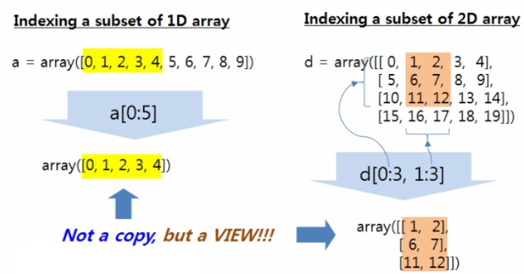

**Takeaways**

- So, through these examples we have seen that we can access **one or multiple elements** of an array using **slicing**,
- Also at times when needed we can extract *subarrays* from an array.
- Also note that, as in the first example my_arr[ 1:5 ], the first element that is extracted is of index 1 and the last element to be extracted is of index 5-1=4.

### 1.7.2. Conditional Indexing in an Array

Here we can filter elements of an array based on some conditions. Below are the steps:

- First we need to create a **boolean array** based on an conditional statement using conditional operators for comparison.
- Then this boolean array is passed as *index of the original array* to return the filtered elements.

```python
arr_ = [1,2,3,4,5]
print(arr_)
arr_>2                                 # TypeError: '>' not supported between instances of 'list' and 'int'
```

```
[1, 2, 3, 4, 5]
```

```
---------------------------------------------------------------------------
TypeError                                 Traceback (most recent call last)
<ipython-input-22-6ca16a9857ac> in <module>
      1 arr_ = [1,2,3,4,5]
      2 print(arr_)
----> 3 arr_>2                                 # TypeError: '>' not supported between instances of 'list' and 'int'

TypeError: '>' not supported between instances of 'list' and 'int'
```

```python
import numpy as np
```

```python
arr_cond = np.arange(2,15)
```

```python
arr_cond
```

```
array([ 2,  3,  4,  5,  6,  7,  8,  9, 10, 11, 12, 13, 14])
```

```python
#arr_cond[[0,2,4]]
arr_cond[[True,False,True,False,True,False,False,False,False,False,False,False,False]]
```

```
array([2, 4, 6])
```

```python
arr_cond[[False, False, False, False, False, False, False,  True,  True,
        True,  True,  True,  True]]
```

```
array([ 9, 10, 11, 12, 13, 14])
```

```python
arr_cond>8
```

```
array([False, False, False, False, False, False, False,  True,  True,
        True,  True,  True,  True])
```

```python
arr_cond[arr_cond>8]
```

```
array([ 9, 10, 11, 12, 13, 14])
```

```python
len(arr_cond)
```

```
13
```

```python
arr_cond[[1,4]]
```

```
array([3, 6])
```

```python
arr_cond[[False, True,False, False, True, False,False,False,False,False,False,False,False]]
```

```
array([3, 6])
```

```python
arr_cond>8                                                # This will return a boolean array
```

```
array([False, False, False, False, False, False, False,  True,  True,
        True,  True,  True,  True])
```

```python
#bool_arr = arr_cond > 5                                   # This will return all the elements of an array where element size > 5
arr_cond[arr_cond > 8]
```

[output not shown]

```python
arr_cond[arr_cond > 5]                                   # This is the same thing without using another object.
```

```
array([ 6,  7,  8,  9, 10, 11, 12, 13, 14])
```

**Takeaways**  
Use conditional indexing to filter out some values like **null or outliers** in an array.  
Given below is a table where you can see what are the various conditional operators available in Python.

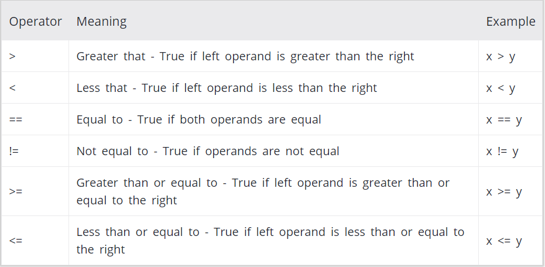

### 1.8. Numpy Array Operations

Here we will observe how we can perform different *arithmatic operations* on Numpy arrays.

### 1.8.1. Numpy Broadcasting

Broadcasting is used to describe how arrays are treated during mathematical operations. The term broadcast is used because a small array is stretched or *broadcasted* over a larger array so that they have compatible sizes.

**Broadcasting Rules:** Starting from the last axis and working backwards, Numpy compares the array dimensions:

- If two dimensions are **equal**, you can **continue**
- If one of the **operand is 1**, **stretch** it to match the largest one
- When one of the **shapes run out of dimension** (because it has less dimensions than the other shape), Numpy will **assign 1** in the comparision process until the other shape's dimensions run out as well.

```python
arr_2d = np.array([[1,2,3],[5,6,7],[8,9,10],[12,13,14]])    # Creating numpy array
arr_2d
```

```
array([[ 1,  2,  3],
       [ 5,  6,  7],
       [ 8,  9, 10],
       [12, 13, 14]])
```

```python
arr_2d.shape
```

```
(4, 3)
```

```python
scaler = 3                                                  # scaler
```

```python
scaler
```

```
3
```

```python
arr_2d +  3                                            # operation with a scaler
```

```
array([[ 4,  5,  6],
       [ 8,  9, 10],
       [11, 12, 13],
       [15, 16, 17]])
```

arr_2d --> 4 * 3

scaler --> 1 * 1  
Here the scaler is stretched and is added to all elements of the array.

```python
arr_1d = np.array([10,10,10])                               # array with different shape
arr_1d.shape
```

```
(3,)
```

```python
print(arr_1d)
print()
print()
print(arr_2d)
```

```
[10 10 10]


[[ 1  2  3]
 [ 5  6  7]
 [ 8  9 10]
 [12 13 14]]
```

```python
arr_2d + arr_1d                                              # operation with a array of different shape
```

```
array([[11, 12, 13],
       [15, 16, 17],
       [18, 19, 20],
       [22, 23, 24]])
```

arr_2d --> 4 * 3

arr_1d --> 1 * 3  
In this case the array with lower dimension i.e. arr_1d is stretched such that it matches the dimensions of arr_2d  
And then addition is performed. Lets learn it better with one diagramatic example.

**Example of Image Broadcasting**

[figure not shown]

From the above image you can see how and when the data is stretched to carry out the mathematical operations. Here we have performed addition on arrays of varying dimensions. Always Remember to stretch the data as per the **broadcasting rules.**

**Now lets look at a different shape of array.**

```python
# arr --> 1 * 4
arr = np.array([[1,1,1,1]])
```

```python
print(arr)
print()
print()
print(arr_2d)
```

```
[[1 1 1 1]]


[[ 1  2  3]
 [ 5  6  7]
 [ 8  9 10]
 [12 13 14]]
```

```python
arr_2d + arr
```

```
---------------------------------------------------------------------------
ValueError                                Traceback (most recent call last)
<ipython-input-19-e6e6a1067920> in <module>
----> 1 arr_2d + arr

ValueError: operands could not be broadcast together with shapes (4,3) (1,4)
```

**If the dimensions do not match it will throw an exception**

**Takeaways**  
Keep a note of the **shape or dimension of the arrays** before applying any mathematical operation and make sure they satisfy the *Numpy broadcasting rules* else value error may occur.

### 1.8.2. Numpy Mathematical Functions

Here you can see a lot of commonly used built-in functions of numpy for mathematical operations. These functions are faster and optimized for large size arrays.

```python
import numpy as np
arr = np.arange(1,11)  # Lets first create a numpy array
arr
```

```
array([ 1,  2,  3,  4,  5,  6,  7,  8,  9, 10])
```

```python
arr[0]=2
```

```python
arr
```

```
array([ 2,  2,  3,  4,  5,  6,  7,  8,  9, 10])
```

```python
arr.min()                                             # Minimum value of array
```

```
2
```

```python
arr.max()                                             # Maximum of the array
```

```
10
```

```python
a = [5,2,3,4,1]
#a.min()
min(a)
#max(a)
```

```
1
```

```python
min(arr)
```

```
2
```

**Min and Max** are used to calculate the **range of array**

```python
arr.argmin()                                          # Index position of minimum of array
```

```
0
```

```python
arr.argmax()                                          # Index position of maximum of array
```

```
9
```

**Argmax** can be used to observe the output of a **softmax layer in Neural Networks**

```python
np.sqrt(arr)                                         # To calculate square root of all elements in an array
```

```
array([1.41421356, 1.41421356, 1.73205081, 2.        , 2.23606798,
       2.44948974, 2.64575131, 2.82842712, 3.        , 3.16227766])
```

**sqrt** is used to calculate **Root Mean Squared Error**

```python
arr.mean()                                           # To calculate mean of all the values in an array
```

```
5.6
```

**Missing values** of a column can be replaced by the **mean** of that column in some datasets**

```python
np.exp(arr)                                          # To calculate exponential value of each element in an array
```

```
array([7.38905610e+00, 7.38905610e+00, 2.00855369e+01, 5.45981500e+01,
       1.48413159e+02, 4.03428793e+02, 1.09663316e+03, 2.98095799e+03,
       8.10308393e+03, 2.20264658e+04])
```

**Exponential** function is used in **Activation Function of Neural Networks**

**Takeaways**  
We have seen that Numpy have various methods to do various mathematical operations like:

- finding *minimum, maximum*,
- calulating *average values*,
- finding exponential value of each element of array. There are more functions available to calculate various statistical parameters.

### 1.8.3. Array Manipulation

Here we will see some numpy functions that can change the structure(shape) of an array.

### 1.8.3.1. Change in Structure or Shape of Array

**Reshape Function**

```python
arr = np.arange(0,16)                                # Using reshape we can change the dimensions of the array
arr
```

```
array([ 0,  1,  2,  3,  4,  5,  6,  7,  8,  9, 10, 11, 12, 13, 14, 15])
```

```python
arr_2D = arr.reshape(4,2)
arr_2D
```

```
---------------------------------------------------------------------------
ValueError                                Traceback (most recent call last)
<ipython-input-10-d41ce0f62da6> in <module>
----> 1 arr_2D = arr.reshape(4,2)
      2 arr_2D

ValueError: cannot reshape array of size 16 into shape (4,2)
```

```python
arr_2D = arr.reshape(4,4)
arr_2D
```

```
array([[ 0,  1,  2,  3],
       [ 4,  5,  6,  7],
       [ 8,  9, 10, 11],
       [12, 13, 14, 15]])
```

**Flatten Function**

```python
arr_2D.flatten()                                      # Flatten is used to convert a 2D array to 1D array
```

```
array([ 0,  1,  2,  3,  4,  5,  6,  7,  8,  9, 10, 11, 12, 13, 14, 15])
```

This is used in **Convolutional Neural Networks** to flatten a 2D-image to individual pixels**

**Transpose Function**

```python
arr_2D.transpose()                                    # Transpose is used to convert the rows into columns and vice-versa
```

```
array([[ 0,  4,  8, 12],
       [ 1,  5,  9, 13],
       [ 2,  6, 10, 14],
       [ 3,  7, 11, 15]])
```

### 1.3.8.2. Merging and Splitting Arrays

```python
arr_x = np.array([[1,2,3,4],[5,6,7,8]])                # Lets create 2 arrays
arr_y = np.array([[21,22,23,24],[25,26,27,28]])
```

```python
arr_x
```

```
array([[1, 2, 3, 4],
       [5, 6, 7, 8]])
```

```python
arr_y
```

```
array([[21, 22, 23, 24],
       [25, 26, 27, 28]])
```

**Concatenate** is used to *join* 2 arrays either along rows or columns

```python
np.concatenate((arr_x, arr_y), axis=1)                # Join 2 arrays along columns
```

```
array([[ 1,  2,  3,  4, 21, 22, 23, 24],
       [ 5,  6,  7,  8, 25, 26, 27, 28]])
```

Set **axis = 1** if you want to merge arrays **columnwise** and for doing it rowwise axis should be set at 0.

**This is used to add new features into a dataset**

```python
arr_z = np.concatenate((arr_x, arr_y), axis=0)         # Join 2 arrays along rows
arr_z
```

```
array([[ 1,  2,  3,  4],
       [ 5,  6,  7,  8],
       [21, 22, 23, 24],
       [25, 26, 27, 28]])
```

After joining arrays we are going to look at ways for splitting arrays.

**Horizontal Split using hsplit**

```python
print(arr_x)
print()
print(arr_y)
print()
print(arr_z)
```

```
[[1 2 3 4]
 [5 6 7 8]]

[[21 22 23 24]
 [25 26 27 28]]

[[ 1  2  3  4]
 [ 5  6  7  8]
 [21 22 23 24]
 [25 26 27 28]]
```

```python
np.hsplit(arr_z, 2)                                # It will split the array into 2 equal halves along the columns
```

```
[array([[ 1,  2],
        [ 5,  6],
        [21, 22],
        [25, 26]]),
 array([[ 3,  4],
        [ 7,  8],
        [23, 24],
        [27, 28]])]
```

**Vertical Split using vsplit**

```python
np.vsplit(arr_z, 2)                                   # It will split the array into 2 equal halves along the rows
```

```
[array([[1, 2, 3, 4],
        [5, 6, 7, 8]]),
 array([[21, 22, 23, 24],
        [25, 26, 27, 28]])]
```

Vertical Splits can be used in **cross-validation in Machine Learning**

**Takeaways**  
Using *concatenate* function we can *merge* arrays columnwise and rowwise. Also arrays can be horizontally and vertically spliited using *hsplit* and *vsplit*.

**Conclusion**  
Numpy is open source add on module to Python.

- By using NumPy you can **speed up** your workflow and *interface with other packages* in the Python ecosystem that use NumPy under the hood.
- A growing plethora of scientific and mathematical Python-based packages are using NumPy arrays; though these typically support Python-sequence input, they convert such input to NumPy arrays prior to processing, and they often output NumPy arrays.
- It provide common **mathematical and numerical routines** in pre-compiled, fast functions.
- It provides *basic routines* for manipulating **large arrays and matrices** of numeric data.

**Key Features**

- NumPy arrays have a **fixed size** decided at the time of creation. *Changing the size of an ndarray will create a new array and delete the original.*
- The elements in a NumPy array are all required to be of the **same data type**, and thus will be the same size in memory.
- NumPy arrays facilitate **advanced mathematical** and other types of **operations** on large numbers of data.